# DATA 605 - Assignment 5

Joshua Sturm

03/04/2018

```r
library(ggplot2)
```

# Problem 1

Choose independently two numbers $B$ and $C$ at random from the interval $[0, 1]$ with uniform density. Prove that $B$ and $C$ are proper probability distributions.

Note that the point $(B,C)$ is then chosen at random in the unit square. Find the probability that:

## Part 1

(a) $B + C < \frac{1}{2}$

## Part 2

(b) $BC < \frac{1}{2}$

## Part 3

(c) $|B - C| < \frac{1}{2}$

## Part 4

(d) $max\{B,C\} < \frac{1}{2}$

## Part 5

(e) $min\{B,C\} < \frac{1}{2}$

# Solutions

$B$ and $C$ each have a 100% probability of $0 \leq B/C \leq 1$, so $B + C$ has a 100% probability of $0 \leq B + C \leq 2$.

```r
B <- runif(n = 5000, min = 0, max = 1)
C <- runif(n = 5000, min = 0, max = 1)
```

## Part 1

1. This is easier to understand visually, so I'll graph the equation. If we let $B = x$ and $C = y$, we can plot the function $f(x) = 0.5 - x$.

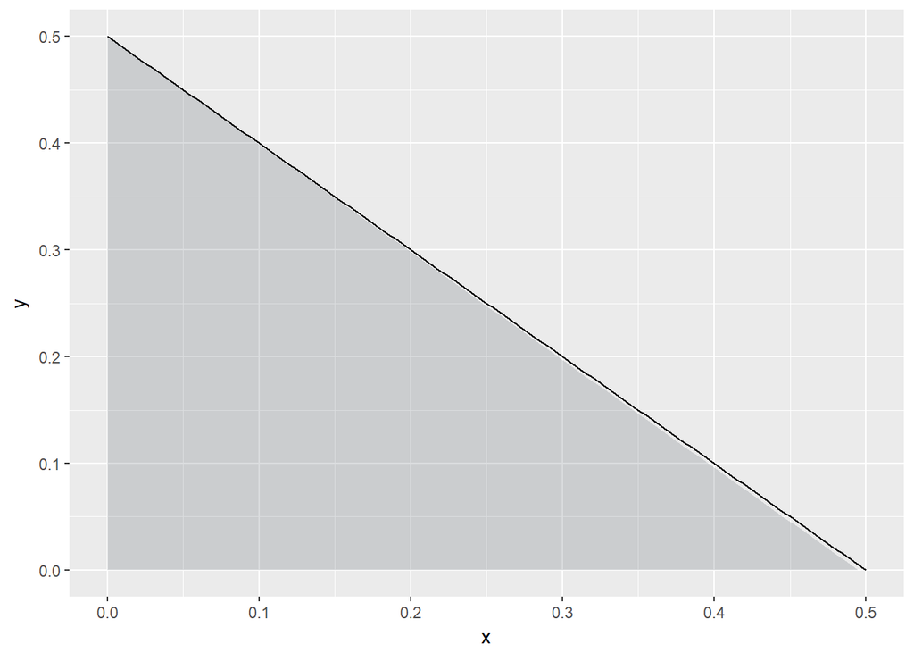

```r
funcShaded <- function(x) {
    y <- seq(0.5,0, length.out = 100)
    y[x < 0 | x > 0.5] <- NA
    return(y)
}

function1 <- function(x) 0.5 - x
ggplot(data = data.frame(x = 0), mapping = aes(x = x)) +
  stat_function(fun = function1) +
  xlim(0, 0.5) +
  ylim(0, 0.5) +
  stat_function(fun=funcShaded, geom="area", fill="#4d535e", alpha=0.2)
```

The probability that $x + y < \frac{1}{2}$ is just the area under the function. In this case, since it's essentially a triangle, we can simply apply the area formula: $\frac{1}{2}*\text{base}*\text{height}$.

```r
base <- 0.5
height <- 0.5
0.5*base*height
```

```
## [1] 0.125
```

## Part 2

$xy = \frac{1}{2} \to y = \frac{0.5}{x} \to y = \frac{1}{2x}$.

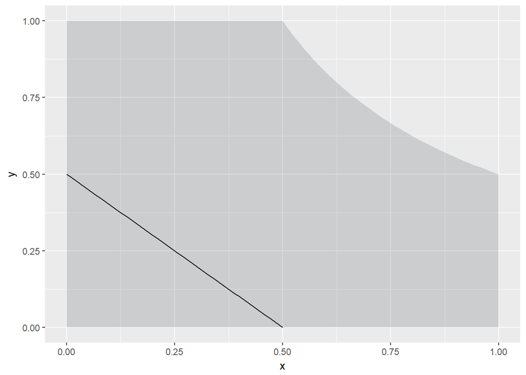

```r
function2 <- function(x) 1/(2*x)
ggplot(data = data.frame(x = 0), mapping = aes(x = x)) +
  stat_function(fun = function1) +
  xlim(0, 1) +
  ylim(0, 1) +
  geom_rect(aes(xmin=0, xmax=0.5, ymin=0,ymax=1), fill="#4d535e", alpha=0.2) +
  stat_function(fun=function2, geom="area", fill="#4d535e", alpha=0.2)
```

Similarly, we need to calculate the area under this curve. We can break it up into two parts: a rectangle (x=0:0.5, y=0:1) and out function $\frac{1}{2x} (x=0.5:1, y=0:\frac{1}{2x}$.\ $0.5 * 1 + \int_{0.5}^{1} \frac{1}{2x}dx = 0.846574$.

```r
integrate(function2, 0.5, 1)[[1]] + 0.5
```

```
## [1] 0.8465736
```

## Part 3

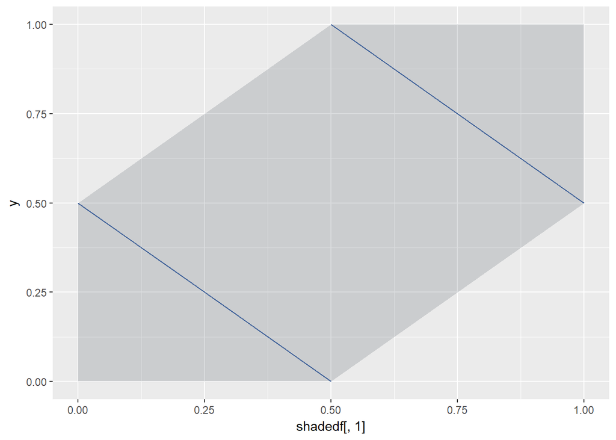

```r
function3 <- function(x) x + 1/2
function31 <- function(x) x - 1/2

shadedx <- c(0,0,0.5,1,1,0.5)
shadedy <- c(0,0.5,1,1,0.5,0)
shadedf <- cbind(shadedx, shadedy)

ggplot() +
  stat_function(fun = function3) +
  stat_function(fun = function31) +
  xlim(0, 1) +
  ylim(0, 1) +
  geom_polygon(aes(shadedf[,1],shadedf[,2]), fill="#4d535e", alpha=0.2) +
  geom_line(aes(x=seq(0,0.5,length.out = 3), y=seq(0.5,0, length.out = 3)), colour = "#44659b") +
  geom_line(aes(x=seq(0.5,1,length.out = 3), y=seq(1,0.5,length.out = 3)), colour="#44659b")
```

## Part 4

$P(B \leq \frac{1}{2})*P(C \leq \frac{1}{2}) = (\frac{1}{2})^{2} = \frac{1}{4}$.

Alternatively, continuing with the area theme, we could plot the 0.5 by 0.5 square, and its area would be given by $0.5 * 0.5 = 0.25$.

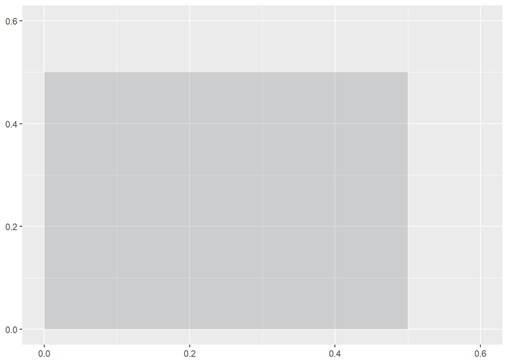

```r
ggplot() +
  xlim(0, 0.6) +
  ylim(0, 0.6) +
  geom_rect(aes(xmin=0, xmax=0.5, ymin=0,ymax=0.5), fill="#4d535e", alpha=0.2)
```

## Part 5

Either $B < \frac{1}{2}$ or $C < \frac{1}{2}$ is needed to satisfy $min\{B,C\} < \frac{1}{2}$.

$P(B < \frac{1}{2} \cup C < \frac{1}{2}) = P(B < \frac{1}{2}) + P(C < \frac{1}{2}) - P(B < \frac{1}{2} \cap C < \frac{1}{2})$.

$P(B < \frac{1}{2}) = \frac{1}{2}$

$P(C < \frac{1}{2}) = \frac{1}{2}$

$P(B < \frac{1}{2} \cap C < \frac{1}{2}) = \frac{1}{4}$

Thus, $\frac{1}{2} + \frac{1}{2} - \frac{1}{4} = \frac{3}{4} = 0.75$.

# References

- https://stackoverflow.com/questions/45301798/ggplot2-how-to-shade-an-area-above-a-function-curve-and-below-a-line